# Regularization and Shrinkage: Why do They Matter?

🔗 Materials: https://github.com/Imperial-College-Data-Science-Society/workshops/tree/master/notebooks/workshop-7

💻 Content covered:

- Motivation
- From linear regression to Ridge
- Connections with Principle Component Analysis
- Lasso
- Example

👾 This lecture will be held online on Microsoft Teams.

🔴 The event will be recorded and will be publicly available.

🎉 Attendance is FREE for members! Whether you are a student at Imperial College or not, sign up to be a member at https://www.icdss.club/joinus

⭐️ We encourage participants of this workshop to have looked at our previous sessions on YouTube.

📖 A schedule of our lecture series is currently available

## Motivation and Setup

Given covariates $x_i = (x_{i1}, x_{i2}, \ldots, x_{id})^\intercal \in \mathbb{R}^d$ and response variables $y_i$, $i = 1, \ldots, n$, so that $$y_i = f(x_i) + \epsilon_i, $$ where $\epsilon_i \sim \mathcal{N}(0, \sigma^2)$ is a Gaussian noise.

For convenience, we write everything in matrix form: for $\epsilon \sim \mathcal{N}(0, \sigma^2 I_n)$, $$ Y = f(X) + \epsilon, $$ where $Y = (y1, \ldots, y_n)^\intercal$, and $X \in \mathbb{R}^{n \times d}$ whose $i$-th row is $x_i$.

E.g. $f(X) = \alpha_0 \mathbf{1} + X \beta_0$, $Y = X \beta_0 + \epsilon$。 In this case, $(\alpha_0, \beta_0) \in \mathbb{R}^{d + 1}$ are the true parameters.

Want to learn $f$.

## Linear regression

Assume $Y = \alpha_0 \mathbf{1} + x\beta_0$.

Least-square (LS) solution: Find the optimal $(\hat{\alpha}, \hat{\beta}) \in \mathbb{R}^{d + 1}$ by minimizing the least-square error: $$ (\hat{\alpha}, \hat{\beta}) = \mathrm{argmin}_{(\alpha, \beta) \in \mathbb{R}^{d + 1}} \| Y - \alpha \mathbf{1} - X\beta \|_2^2. $$

Let $\tilde{X} = [\mathbf{1} \ X]$ be the design matrix with an intercept. Simple linear algebra gives the LS solution: $$ (\hat{\alpha}, \hat{\beta}^\intercal)^\intercal = (\tilde{X}^T \tilde{X})^{-1} \tilde{X}^\intercal Y. $$

Caveat: For the LS solution to be well-defined, the $d \times d$ matrix $\tilde{X}^T \tilde{X}$ needs to be invertible, or equivalently, $\tilde{X}$ need to have full-rank ($n \geq d$).

Problem: What about when $d > > n$?

E.g. 1. In cancer prediction problems, it is common to have thousands of gene expressions as your covariates, but only a few hundreds of patients' record.

E.g. 2. In a customer behaviour analysis where you are given whether a customer has purchased a product from Amazon as the response, and some features (type of product, price, time of visit etc.) as covariates. You don't really want to *predict* buy/not buy, but to understand which features, amongst a handful of them, are most correlated to the purchase behaviour.

#### Summary

LS is good, but does not give us an answer when:

1. The problem is high-dimensional and we have more features than cases.
2. We are interested in selecting the features that are most "important".

## Ridge Regression

Ridge solution: Find the optimal $(\hat{\alpha}, \hat{\beta}) \in \mathbb{R}^{d + 1}$ by minimizing the least-square error **with $L_2$-penalty**: $$ (\hat{\alpha}, \hat{\beta}) = \mathrm{argmin}_{(\alpha, \beta) \in \mathbb{R}^{d + 1}} \| Y - \alpha \mathbf{1} - X\beta \|_2^2 \color{red}{ + \lambda \| \beta \|_2^2 }, $$ where $\| \beta \|_2^2 = \sum_{j = 1}^d \beta_j^2$ is called the penalty/regularization term, and $\lambda > 0$ is a hyperparameter we need to choose (often by cross-validation).

Why adding in a regularization helps?

Under some conditions (columns of $X$ are standardized to have zero mean and unit variance), the Ridge solution can be derived analytically: \begin{align*} \hat{\alpha} &= \frac{1}{n} \sum_{i = 1}^{n} Y_i = 0, \\ \hat{\beta} &= (X^\intercal X + \lambda I_n)^{-1} X^{\intercal}Y, \end{align*}

**Key observations**: Comparing with LS solution $\hat{\beta} = (X^\intercal X)^{-1} X^{\intercal}Y$,

- $(X^\intercal X + \lambda I_n)$ is always invertible for **any** $X$, as long as $\lambda > 0$. So the Ridge solution is always well-defined.
- Adding the penalty term **shrinks** the fitted coefficients in $\hat{\beta}$ towards zero (more on this later).
- $\hat{\beta}$ is now biased, but always has a smaller variance for a judicious choice of $\lambda$ (bias-variance trade-off):

  Mean-Square Error = Variance + $\textrm{Bias}^2$.
- We normally do **not** penalize the intercept term!

### Choosing $\lambda$

The optimal $\lambda$ is often chosen by cross-validation:

1. Split training data into various subsets, called **folds**.
2. For each $\lambda$ over a pre-defined grid of values $\lambda_1, \ldots, \lambda_k$, calculate Ridge solution from all but one folds, compute out-of-sample error on the other fold, and repeat to get an averaged loss.
3. Pick the $\lambda$ that gave the smallest averaged cross-validation loss.

[figure not shown]

## Connections with PCA

Idea of Principal Value Analaysis (PCA):

Find the directions along which the **features** $X$ have the largest variance (i.e. most informative), and only look at the first few of them.

- The variance is quantified by the **eigenvalues** of the matrix $X^\intercal X$.
- The directions are given by the **eigenvectors**, called principal components (PCs).

**Principal component regression**: Use the first, say $s$, eigenvectors as the covariates, and perform least-square fit to find $\hat{\beta}$.

[figure not shown]

Principal component regression:

- 1: Perform PCA to create PCs as our new input features
- 2: Use these PCs as input features to train our model for a least-square fit.
- 3: Transform these PCs back to the original input features, in order to make predictions on the actual dataset.

[figure not shown]

Adding the penalty term in Ridge regression effectively shrinks the Ridge solution $\hat{\beta}$ according to the **eigenvalues** of the matrix $X^\intercal X$.

- Let $\hat{\beta}^{(LS)}$ = LS solution, $\hat{\beta}_s^{(PC)}$ = PC regression with $s$ PCs, $\hat{\beta}_\lambda^{(R)}$ = Ridge solution with regularization parameter $\lambda > 0$.
- Let $D_1 \geq D_2 \geq \ldots \geq D_d$ be the eigenvalues of $X^\intercal X$ with corresponding eigenvectors $u_1, \ldots, u_d$.

**Fact**: The fitted values can be rewritten as \begin{align*} X \hat{\beta}^{(LS)} &= \sum_{j = 1}^{d} (u_j^\intercal Y) u_j \\ X \hat{\beta}_s^{(PC)} &= \sum_{j = 1}^s (u_j^\intercal Y) u_j \\ X \hat{\beta}_\lambda^{(R)} &= \sum_{j = 1}^d \color{blue}{\frac{D_j^2}{D_j^2 + \lambda}} (u_j^\intercal Y) u_j \end{align*}

**Key observations**:

- Ridge shrinks the directions with the smallest eigenvalues the most.
- $\lambda$ ↑, shrinkage ↑

## Lasso Regression

Lasso solution: Find the optimal $(\hat{\alpha}, \hat{\beta}) \in \mathbb{R}^{d + 1}$ by minimizing the least-square error **with $L_1$-penalty**: $$ (\hat{\alpha}, \hat{\beta}) = \mathrm{argmin}_{(\alpha, \beta) \in \mathbb{R}^{d + 1}} \frac{1}{2}\| Y - \alpha \mathbf{1} - X\beta \|_2^2 \color{red}{ + \lambda \| \beta \|_1 }, $$ where $\| \beta \|_1 = \sum_{j = 1}^d |\beta_j|$, $\lambda > 0$ is a hyperparameter we need to choose.

[figure not shown]

**Key observations**:

- Lasso is more likely to give rise to $\hat{\beta}$ that are **exactly** zero.
- Lasso solutions has nice theoretical properties: with judicious choice of $\lambda$ and under regularity conditoins, $\hat{\beta} \approx \beta_0$ with high probability.
- Lasso can be combined with Ridge to give the *elastic net* penalty: for $\alpha \in [0, 1]$ $$ \lambda \left( \alpha \| \beta \|_2^2 + (1 - \alpha) \| \beta \|_1 \right). $$

## Experiments (Prostate Cancer)

See the notebook here:

https://github.com/Imperial-College-Data-Science-Society/workshops/tree/master/notebooks/workshop-7

### Comparing solution paths

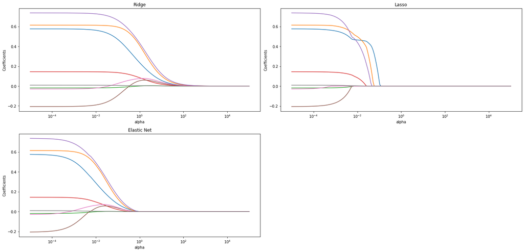

```python
fig = plt.figure(figsize=(20, 14))
ax = fig.add_subplot(321)
ax2 = fig.add_subplot(322)
ax3 = fig.add_subplot(323)

ax.plot(alphas, ridge_sol_path)
ax.set_xscale('log')
ax.set_xlabel('alpha')
ax.set_ylabel('Coefficients')
ax.set_title("Ridge")

ax2.plot(alphas, lasso_sol_path)
ax2.set_xscale('log')
ax2.set_xscale('log')
ax2.set_xlabel('alpha')
ax2.set_ylabel('Coefficients')
ax2.set_title("Lasso")

ax3.plot(alphas, enet_sol_path)
ax3.set_xscale('log')
ax3.set_xscale('log')
ax3.set_xlabel('alpha')
ax3.set_ylabel('Coefficients')
ax3.set_title("Elastic Net")

fig.tight_layout()
plt.show()
```

## Other Forms of Regularization

1. Other penalty functions: $L_q, q > 0$, grouped lasso.
2. The SVM obective can be written in a form involving a regularization term.
3. Dropouts in neural network.
4. Double descent (overfitting leads to lower out-of-sample error).

## References

Hastie, Trevor, Tibshirani, Robert and Friedman, Jerome. *The Elements of Statistical Learning*. New York, NY, USA: Springer New York Inc., 2001.

Rajen Shah. Lecture Notes on Modern Statistical Methods. 2019. http://www.statslab.cam.ac.uk/~rds37/teaching/modern_stat_methods/notes_MSM.pdf